# Homework5

Sichao Zhou

2019/11/21

**1. Consider the automobile gasoline mileage data in Table B.3.**  
**a. Build a linear regression model relating gasoline mileage $y$ to engine displacement $x_1$ and the type of transmission $x_{11}$ (1 = automatic, 0 = manual). Does the type of transmission significantly affect the mileage performance?**

```r
df<-read.csv(file.choose())
df<-na.omit(df)
attach(df)
mod1<-lm(y~x1+x11)
summary(mod1)
```

```
##
## Call:
## lm(formula = y ~ x1 + x11)
##
## Residuals:
##     Min      1Q  Median      3Q     Max
## -6.6322 -2.0064 -0.0412  1.4367  7.0123
##
## Coefficients:
##              Estimate Std. Error t value Pr(>|t|)
## (Intercept) 33.472664   1.617838  20.690  < 2e-16 ***
## x1          -0.046717   0.008969  -5.209 1.74e-05 ***
## x11         -0.096797   2.317964  -0.042    0.967
## ---
## Signif. codes:  0 '***' 0.001 '**' 0.01 '*' 0.05 '.' 0.1 ' ' 1
##
## Residual standard error: 3.177 on 27 degrees of freedom
## Multiple R-squared:  0.7607, Adjusted R-squared:  0.743
## F-statistic: 42.91 on 2 and 27 DF,  p-value: 4.129e-09
```

Null hypothesis,H0:β11=0. Alternative hypotheses: Ha:β11 not equal to zero.  
From the Variance Table one can see t-value=-0.042 the corresponding P-value(>t) = 0.967 >0.05. So, we fall to reject null hypothesis, that indicates the type of transmission significantly not affect the mileage performance.  
**b. Modify the model developed in part a to include an interaction between engine displacement and the type of transmission. What conclusions can you draw about the effect of the type of transmission on gasoline mileage? Interpret the parameters in this model.**

```r
mod2<-lm(y~x1+x11+x1:x11)
summary(mod2)
```

```
##
## Call:
## lm(formula = y ~ x1 + x11 + x1:x11)
##
## Residuals:
##     Min      1Q  Median      3Q     Max
## -5.9000 -1.0244 -0.0019  1.4175  4.7244
##
## Coefficients:
##              Estimate Std. Error t value Pr(>|t|)
## (Intercept)  42.79121    2.75787  15.516 1.16e-14 ***
## x1           -0.11851    0.02005  -5.912 3.09e-06 ***
## x11         -13.17592    3.88932  -3.388 0.002253 **
## x1:x11        0.08276    0.02152   3.845 0.000699 ***
## ---
## Signif. codes:  0 '***' 0.001 '**' 0.01 '*' 0.05 '.' 0.1 ' ' 1
##
## Residual standard error: 2.585 on 26 degrees of freedom
## Multiple R-squared:  0.8474, Adjusted R-squared:  0.8298
## F-statistic: 48.14 on 3 and 26 DF,  p-value: 9.396e-11
```

Null hypothesis,H0:βi=0. Alternative hypotheses: Ha:βi not equal to zero. From the Variance Table one can see t-value=3.845 the corresponding P-value(>t) = 0.000699 <0.05. So, we reject null hypothesis, that indicates the interaction between engine displacement and the type of transmission have significantly affect the mileage performance.we need use ridge Regression is a technique for analyzing multiple regression data that suffer from multicollinearity.

**2. Estimate the parameters in a model for the gasoline mileage data in Table B.3 using ridge regression with all independent variables.**  
**a. Select an appropriate value of the tuning parameter $\lambda$. Is the resulting model adequate?**

```r
#########################################
library(glmnet)
library (lindia)
df <- as.data.frame(apply(df, 2, scale))
y <- df$y
X <- as.matrix(df[,-1])
fit_OLS <- lm(y~X)
summary(fit_OLS)
```

```
##
## Call:
## lm(formula = y ~ X)
##
## Residuals:
##      Min       1Q   Median       3Q      Max
## -0.85269 -0.26663 -0.07158  0.23784  0.83781
##
## Coefficients:
##               Estimate Std. Error t value Pr(>|t|)
## (Intercept) -3.392e-16  9.400e-02   0.000   1.0000
## Xx1         -1.402e+00  1.045e+00  -1.341   0.1964
## Xx2         -4.927e-01  6.255e-01  -0.788   0.4411
## Xx3          1.526e+00  1.168e+00   1.306   0.2078
## Xx4          6.613e-02  1.372e-01   0.482   0.6357
## Xx5          4.933e-01  2.658e-01   1.856   0.0799 .
## Xx6          5.435e-02  2.206e-01   0.246   0.8082
## Xx7         -3.380e-01  3.279e-01  -1.031   0.3162
## Xx8          6.067e-01  4.372e-01   1.388   0.1822
## Xx9         -3.606e-01  2.931e-01  -1.230   0.2344
## Xx10        -7.680e-01  8.853e-01  -0.868   0.3971
## Xx11         4.582e-02  2.169e-01   0.211   0.8350
## ---
## Signif. codes:  0 '***' 0.001 '**' 0.01 '*' 0.05 '.' 0.1 ' ' 1
##
## Residual standard error: 0.5148 on 18 degrees of freedom
## Multiple R-squared:  0.8355, Adjusted R-squared:  0.7349
## F-statistic:  8.31 on 11 and 18 DF,  p-value: 5.231e-05
```

```r
y_predicted0=
sst0 <- sum((y - mean(y))^2)
sse0 <- sum((fitted(fit_OLS) - y)^2)
sst0
```

```
## [1] 29
```

```r
sse0
```

```
## [1] 4.770956
```

```r
rsq0 <- 1 - sse0 / sst0
rsq0
```

```
## [1] 0.8354843
```

```r
#########################################
lambdas <- 10^seq(3, -2, by = -.1)
fit <- glmnet(X, y, alpha = 0, lambda = lambdas)
summary(fit)
```

```
##           Length Class     Mode
## a0         51    -none-    numeric
## beta      561    dgCMatrix S4
## df         51    -none-    numeric
## dim         2    -none-    numeric
## lambda     51    -none-    numeric
## dev.ratio  51    -none-    numeric
## nulldev     1    -none-    numeric
## npasses     1    -none-    numeric
## jerr        1    -none-    numeric
## offset      1    -none-    logical
## call        5    -none-    call
## nobs        1    -none-    numeric
```

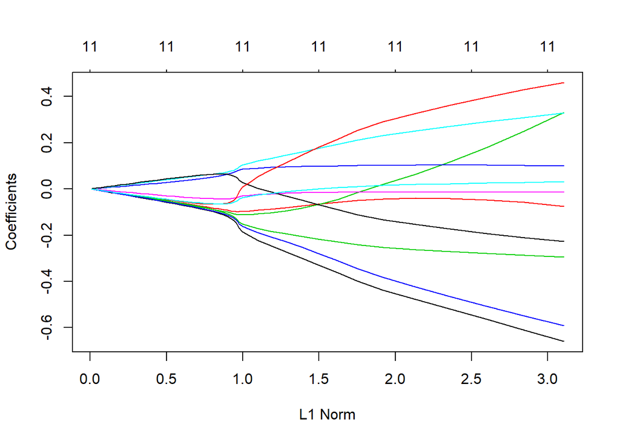

```r
plot(fit)
```

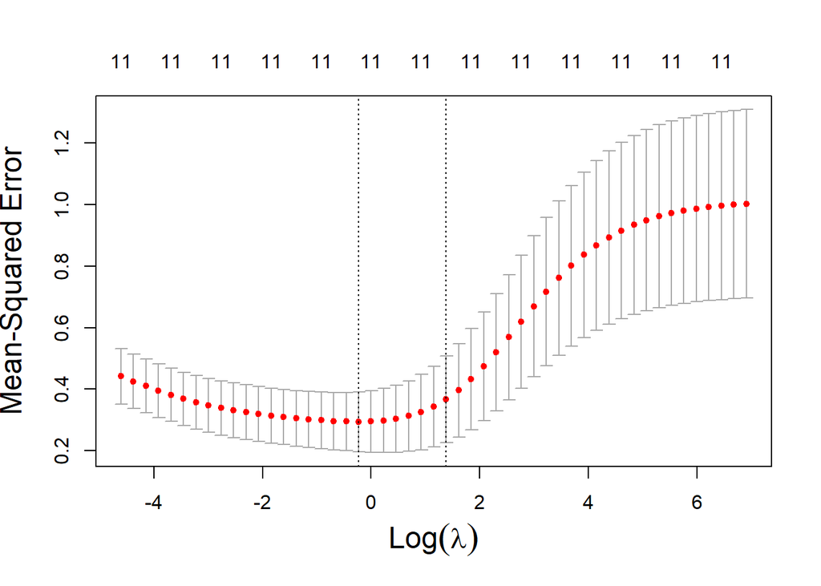

```r
set.seed(2019)
cv_fit <- cv.glmnet(X, y, alpha = 0, lambda = lambdas)
plot(cv_fit, cex.lab=1.5)
```

```r
opt_lambda <- cv_fit$lambda.min
opt_lambda
```

```
## [1] 0.7943282
```

```r
best_ridge <- glmnet(X, y, alpha = 0, lambda = opt_lambda)
coef(best_ridge)
```

```
## 12 x 1 sparse Matrix of class "dgCMatrix"
##                        s0
## (Intercept) -2.908190e-16
## x1          -1.265013e-01
## x2          -9.441815e-02
## x3          -1.033790e-01
## x4           6.827336e-02
## x5           7.708034e-02
## x6          -4.198121e-02
## x7           6.058775e-02
## x8          -5.591189e-02
## x9          -1.133640e-01
## x10         -1.193405e-01
## x11         -6.145213e-02
```

```r
y_predicted <- predict(best_ridge, newx = X)
```

The tuning parameter $\lambda$= 0.7943282, the resulting model adequate.

**b. How much inflation in the residual sum of squares has resulted from the use of ridge regression?**

```r
# Sum of Squares Total and Error
sst <- sum((y - mean(y))^2)
sse <- sum((y_predicted - y)^2)
sst
```

```
## [1] 29
```

```r
sse
```

```
## [1] 7.022887
```

From the results one can see the sum of Squares Error increasing from 4.770956 to 7.022887 use of ridge regression.

**c. How much reduction in $R^2$ has resulted from the use of ridge regression?**

```r
# R squared
rsq <- 1 - sse / sst
rsq
```

```
## [1] 0.7578315
```

From the results one can see the sum of $R^2$ decreasing from 0.8354843 to 0.7578315 use of ridge regression.